# Project 1: Wrangling, Exploration, Visualization

SDS322E

## Data Wrangling, Exploration, Visualization

### Roshan Shaik

#### Introduction

Climate change has been a major topic of discussion among the scientific and political community in recent years. Numerous organizations have been trying to educate the public on environmental awareness and the many issues that are negatively affecting the Earth. Among those issues is air pollution, which is especially prominent in urban cities that are very populated. I used my old Biostats data for the first dataset, which looks into factors that may cause air pollution to fluctuate in different cities in the United States. The three variables that were collected in this dataset are population density, average annuall temperature, and AQI. AQI is is a numerical range of values that categorizes air safety levels. The second dataset is from a study of the healthiest cities in America. The researchers evaluated the overall healthiest cities using four variables: healthcare, food, fitness, green space. Combining these two datasets will allow us to see how air pollution affects the ‘healthiness’ of a city, and to what extent.

```r
library(tidyverse)
library(knitr)
health <- read_csv("Sheet 2.csv")
pollution <- read_csv("Sheet 1.csv")
pollution <- pollution %>% rename(City = "Cities")
```

#### Tidying: Reshaping

```r
pollution %>% pivot_wider(names_from = City, values_from = AQI)
```

```
## # A tibble: 60 x 62
##    Population_Dens… Average_Temp `Minneapolis, M… `Phoenix, AZ` `Columbus, OH`
##               <dbl>        <dbl>            <dbl>         <dbl>          <dbl>
##  1            2594.         46.1             38.3          NA             NA
##  2            3165.         75               NA            61.1           NA
##  3            2605.         53               NA            NA             33.5
##  4            4005.         61.3             NA            NA             NA
##  5            3028.         52.4             NA            NA             NA
##  6            1414.         62.9             NA            NA             NA
##  7            2221.         48.8             NA            NA             NA
##  8            2031.         48.8             NA            NA             NA
##  9            1707.         61.1             NA            NA             NA
## 10            2098          60.6             NA            NA             NA
## # … with 50 more rows, and 57 more variables: `Stockton, CA` <dbl>, `Seattle,
## #   WA` <dbl>, `Birmingham, AL` <dbl>, `Rochester, NY` <dbl>, `Grand Rapids,
## #   MI` <dbl>, `Atlanta, GA` <dbl>, `Oklahoma City, OK` <dbl>, `Orlando,
## #   FL` <dbl>, `Memphis, TN` <dbl>, `Miami, FL` <dbl>, `Austin, TX` <dbl>, `San
## #   Diego, CA` <dbl>, `New York, NY` <dbl>, `Fayetteville, NC` <dbl>, `Fresno,
## #   CA` <dbl>, `Houston, TX` <dbl>, `St. Louis, MO` <dbl>, `San Fransisco,
## #   CA` <dbl>, `Reno, NV` <dbl>, `Boise, ID` <dbl>, `Charlotte, NC` <dbl>,
## #   `Portland, OR` <dbl>, `Wilmington, NC` <dbl>, `Philadelphia, PA` <dbl>,
## #   `New Orleans, LA` <dbl>, `Omaha, NE` <dbl>, `Tulsa, OK` <dbl>, `Colorado
## #   Springs, CO` <dbl>, `Syracuse, NY` <dbl>, `Rapid City, SD` <dbl>, `Toledo,
## #   OH` <dbl>, `Lexington, KY` <dbl>, `Fort Wayne, IN` <dbl>, `Buffalo,
## #   NY` <dbl>, `Mobile, AL` <dbl>, `Gainesville, FL` <dbl>, `Salisbury,
## #   MD` <dbl>, `Redding, CA` <dbl>, `Columbia, SC` <dbl>, `Jackson, TN` <dbl>,
## #   `Ogden, UT` <dbl>, `Tuscaloosa, AL` <dbl>, `Albany, NY` <dbl>, `Bismarck,
## #   ND` <dbl>, `Las Vegas, NV` <dbl>, `Richmond, VA` <dbl>, `Wenatchee,
## #   WA` <dbl>, `Wichita, KS` <dbl>, `Boulder, CO` <dbl>, `Appleton, WI` <dbl>,
## #   `Springfield, OH` <dbl>, `Lancaster, PA` <dbl>, `Killeen, TX` <dbl>,
## #   `Riverside, CA` <dbl>, `Albany, GA` <dbl>, `Las Cruces, NM` <dbl>,
## #   `Modesto, CA` <dbl>
```

```r
wide2 <- health %>% pivot_wider(names_from = City, values_from = Healthcare)
wide2 %>% pivot_longer(6:187, names_to = "City", values_to = "Healthcare") %>%
    head()
```

```
## # A tibble: 6 x 7
##   `Overall Rank` `Total Score`  Food Fitness `Green Space` City       Healthcare
##            <dbl>         <dbl> <dbl>   <dbl>         <dbl> <chr>           <dbl>
## 1              1          69.1     1      59             1 San Franc…         10
## 2              1          69.1     1      59             1 Seattle, …         NA
## 3              1          69.1     1      59             1 Portland,…         NA
## 4              1          69.1     1      59             1 San Diego…         NA
## 5              1          69.1     1      59             1 Honolulu,…         NA
## 6              1          69.1     1      59             1 Washingto…         NA
```

#### Joining/Merging

```r
combined_data <- inner_join(pollution, health, by = "City")
head(combined_data)
```

```
## # A tibble: 6 x 10
##   City  Population_Dens… Average_Temp   AQI `Overall Rank` `Total Score`
##   <chr>            <dbl>        <dbl> <dbl>          <dbl>         <dbl>
## 1 Minn…            2594.         46.1  38.3             15          57.7
## 2 Phoe…            3165.         75    61.1             70          47.3
## 3 Colu…            2605.         53    33.5            123          41.5
## 4 Stoc…            4005.         61.3  52.3            152          37.1
## 5 Seat…            3028.         52.4  44.7              2          65.7
## 6 Birm…            1414.         62.9  46.9            154          36.6
## # … with 4 more variables: Healthcare <dbl>, Food <dbl>, Fitness <dbl>, `Green
## #   Space` <dbl>
```

```r
nrow(health)
```

```
## [1] 182
```

```r
nrow(pollution)
```

```
## [1] 60
```

```r
nrow(combined_data)
```

```
## [1] 42
```

#### Wrangling

```r
combined_data <- combined_data %>% select(-`Overall Rank`)
combined_data <- combined_data %>% rename(Total_Health_Score = "Total Score")
combined_data <- combined_data %>% mutate(AQI_Category = case_when(AQI <=
    50 ~ "good", AQI > 50 ~ "moderate"))
```

The combined data contained a variable ‘Overall Rank’, which ranks each city based on Health score. However, since not all cities from the original ‘health’ dataset are present in the combined one, this variable would not make sense.

```r
combined_data <- combined_data %>% mutate(AQI_Category = str_replace(AQI_Category,
    "good", "Good"))
combined_data <- combined_data %>% mutate(AQI_Category = str_replace(AQI_Category,
    "moderate", "Moderate"))
combined_data %>% group_by(AQI_Category) %>% summarize(n()) %>%
    kable()
```

| AQI_Category | n() |
| --- | --- |
| Good | 36 |
| Moderate | 6 |

```r
combined_data %>% group_by(AQI_Category) %>% summarize(mean(Total_Health_Score)) %>%
    kable()
```

| AQI_Category | mean(Total_Health_Score) |
| --- | --- |
| Good | 46.22222 |
| Moderate | 45.62167 |

```r
combined_data %>% group_by(AQI_Category) %>% summarize(sd(Total_Health_Score))
```

```
## # A tibble: 2 x 2
##   AQI_Category `sd(Total_Health_Score)`
##   <chr>                           <dbl>
## 1 Good                             9.10
## 2 Moderate                         9.06
```

```r
combined_data %>% filter(Average_Temp > 59) %>% summarize(mean_total_health_score = mean(Total_Health_Score)) %>%
    kable()
```

| mean_total_health_score |
| --- |
| 44.00045 |

```r
combined_data %>% filter(Average_Temp < 59) %>% summarize(mean_total_health_score = mean(Total_Health_Score)) %>%
    kable()
```

| mean_total_health_score |
| --- |
| 48.486 |

```r
combined_data %>% arrange(desc(Total_Health_Score))
```

```
## # A tibble: 42 x 10
##    City  Population_Dens… Average_Temp   AQI Total_Health_Sc… Healthcare  Food
##    <chr>            <dbl>        <dbl> <dbl>            <dbl>      <dbl> <dbl>
##  1 Seat…            3028.         52.4  44.7             65.7         14     6
##  2 Port…            3528.         52.3  40.9             65.6         20     3
##  3 San …            4037          62.1  68.8             62.9         26     4
##  4 Aust…            2605.         68.7  39.6             59.1         19    13
##  5 Minn…            2594.         46.1  38.3             57.7         24    24
##  6 Orla…            2527.         71.8  31.9             55.6         33    17
##  7 Bois…            2613.         51.8  48.7             55.3         52    47
##  8 Atla…            1707.         61.1  43.2             55.2         43    14
##  9 New …            5319.         53.4  43.7             54.4         98     2
## 10 Rich…            1938.         58.6  32.2             53.0         25    67
## # … with 32 more rows, and 3 more variables: Fitness <dbl>, `Green
## #   Space` <dbl>, AQI_Category <chr>
```

```r
combined_data
```

```
## # A tibble: 42 x 10
##    City  Population_Dens… Average_Temp   AQI Total_Health_Sc… Healthcare  Food
##    <chr>            <dbl>        <dbl> <dbl>            <dbl>      <dbl> <dbl>
##  1 Minn…            2594.         46.1  38.3             57.7         24    24
##  2 Phoe…            3165.         75    61.1             47.3        129    34
##  3 Colu…            2605.         53    33.5             41.5         71    99
##  4 Stoc…            4005.         61.3  52.3             37.1        134   121
##  5 Seat…            3028.         52.4  44.7             65.7         14     6
##  6 Birm…            1414.         62.9  46.9             36.6        123   151
##  7 Roch…            2221.         48.8  30               50.1         82    38
##  8 Gran…            2031.         48.8  33.6             48.8         49    70
##  9 Atla…            1707.         61.1  43.2             55.2         43    14
## 10 Okla…            2098          60.6  42.7             38.6         84   148
## # … with 32 more rows, and 3 more variables: Fitness <dbl>, `Green
## #   Space` <dbl>, AQI_Category <chr>
```

```r
combined_data %>% select(3:9) %>% summarize_all(mean)
```

```
## # A tibble: 1 x 7
##   Average_Temp   AQI Total_Health_Score Healthcare  Food Fitness `Green Space`
##          <dbl> <dbl>              <dbl>      <dbl> <dbl>   <dbl>         <dbl>
## 1         58.9  41.4               46.1       94.8  79.2    88.7          86.9
```

```r
combined_data %>% select(3:9) %>% summarize_all(max)
```

```
## # A tibble: 1 x 7
##   Average_Temp   AQI Total_Health_Score Healthcare  Food Fitness `Green Space`
##          <dbl> <dbl>              <dbl>      <dbl> <dbl>   <dbl>         <dbl>
## 1         76.3  70.2               65.7        178   177     176           178
```

```r
combined_data %>% select(3:9) %>% summarize_all(min)
```

```
## # A tibble: 1 x 7
##   Average_Temp   AQI Total_Health_Score Healthcare  Food Fitness `Green Space`
##          <dbl> <dbl>              <dbl>      <dbl> <dbl>   <dbl>         <dbl>
## 1         43.7  24.1               29.2         14     2       9             2
```

```r
combined_data %>% select(3:9) %>% summarize_all(sd)
```

```
## # A tibble: 1 x 7
##   Average_Temp   AQI Total_Health_Score Healthcare  Food Fitness `Green Space`
##          <dbl> <dbl>              <dbl>      <dbl> <dbl>   <dbl>         <dbl>
## 1         8.42  10.7               8.99       49.7  57.5    53.5          57.3
```

```r
combined_data %>% summarize_all(function(x) sum(is.na(x)))
```

```
## # A tibble: 1 x 10
##    City Population_Dens… Average_Temp   AQI Total_Health_Sc… Healthcare  Food
##   <int>            <int>        <int> <int>            <int>      <int> <int>
## 1     0                0            0     0                0          0     0
## # … with 3 more variables: Fitness <int>, `Green Space` <int>,
## #   AQI_Category <int>
```

```r
combined_data %>% pivot_wider(names_from = AQI_Category, values_from = Total_Health_Score)
```

```
## # A tibble: 42 x 10
##    City  Population_Dens… Average_Temp   AQI Healthcare  Food Fitness
##    <chr>            <dbl>        <dbl> <dbl>      <dbl> <dbl>   <dbl>
##  1 Minn…            2594.         46.1  38.3         24    24      64
##  2 Phoe…            3165.         75    61.1        129    34      85
##  3 Colu…            2605.         53    33.5         71    99     148
##  4 Stoc…            4005.         61.3  52.3        134   121     165
##  5 Seat…            3028.         52.4  44.7         14     6      25
##  6 Birm…            1414.         62.9  46.9        123   151     151
##  7 Roch…            2221.         48.8  30           82    38      68
##  8 Gran…            2031.         48.8  33.6         49    70      69
##  9 Atla…            1707.         61.1  43.2         43    14      23
## 10 Okla…            2098          60.6  42.7         84   148     134
## # … with 32 more rows, and 3 more variables: `Green Space` <dbl>, Good <dbl>,
## #   Moderate <dbl>
```

After summarizing all the data, we can see that there are 36 cities in the combined dataset that have an AQI of less than 50, which puts them in the ‘good’ air quality category. This category is satisfactory and air pollution poses little to no risk. 6 of the cities have an AQI of greater than 50, which puts them in the ‘moderate’ category. This category may pose a risk for some people. The mean health score for ‘Good’ cities is 46.2, while the mean health score for ‘Moderate’ cities is 45.6. Although we would have expected the health scores for the less polluted cities to be higher, the difference is not significant enough to confirm that. Therefore, we cannot make any conclusions on the effect of AQI on total health score. However, there is a difference in health score based on average annual temperature. For cities that have a annual temperature higher than the mean of all cities (59), the mean total health score is 44. For cities that have a annual temperature lower than 59, the mean total health score is 48.5. So cities with a lower temperature seem to be generally healthier.

#### Visualizing

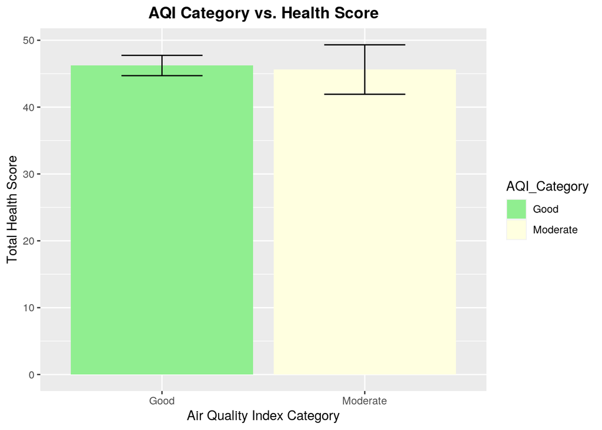

```r
combined_data %>% ggplot(aes(AQI_Category, Total_Health_Score,
    fill = AQI_Category)) + geom_bar(stat = "summary", fun = mean) +
    xlab("Air Quality Index Category") + ylab("Total Health Score") +
    geom_errorbar(stat = "summary", width = 0.4) + ggtitle("AQI Category vs. Health Score") +
    theme(plot.title = element_text(hjust = 0.5)) + theme(plot.title = element_text(face = "bold")) +
    scale_fill_manual(values = c(Good = "LightGreen", Moderate = "LightYellow"))
```

This barplot shows that the total health score is approximately the same for cities with ‘good’ air quality and cities with ‘moderate’ air quality. In other words, there is no distinct difference in the healthiness of a city based on the AQI category. However, there is still a possibility of a trend or corellation that can only be seen in a scatterplot.

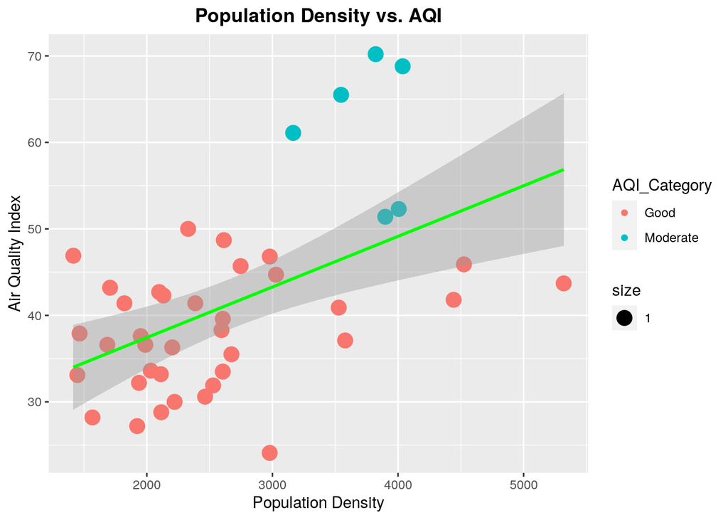

```r
combined_data %>% ggplot(aes(Population_Density, AQI)) + geom_point(aes(color = AQI_Category,
    size = 1)) + xlab("Population Density") + ylab("Air Quality Index") +
    geom_smooth(method = "lm", color = "green") + ggtitle("Population Density vs. AQI") +
    theme(plot.title = element_text(hjust = 0.5)) + theme(plot.title = element_text(face = "bold"))
```

This plot shows a positive relationship between population density and air quality index, which is consistent with my expectations. Cities that are more densely populated have a higher air quality index, showing that there is more pollution and the air quality is worse. Cities that are less dense in terms of population have better air quality.

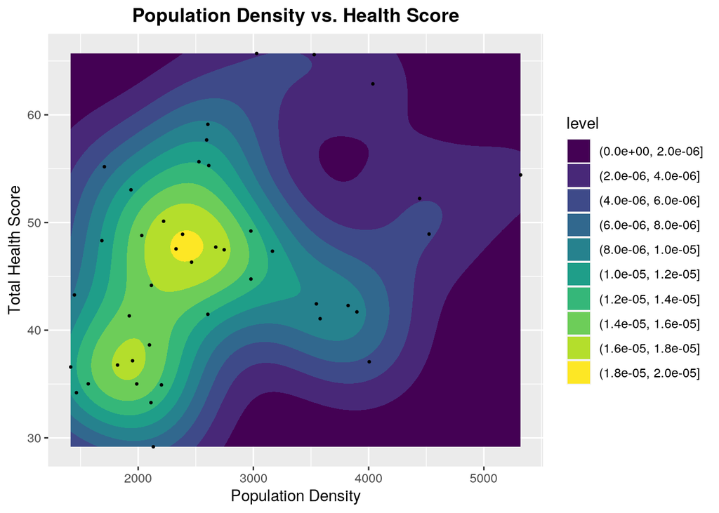

```r
combined_data %>% ggplot(aes(x = Population_Density, y = Total_Health_Score)) +
    geom_density2d_filled() + geom_jitter(size = 0.5) + xlab("Population Density") +
    ylab("Total Health Score") + ggtitle("Population Density vs. Health Score") +
    theme(plot.title = element_text(hjust = 0.5)) + theme(plot.title = element_text(face = "bold"))
```